# Model validation. Offline evaluation

### P(E|X)

Here we study the distribution of the error conditioned to the model's inputs.

#### RESIDUE

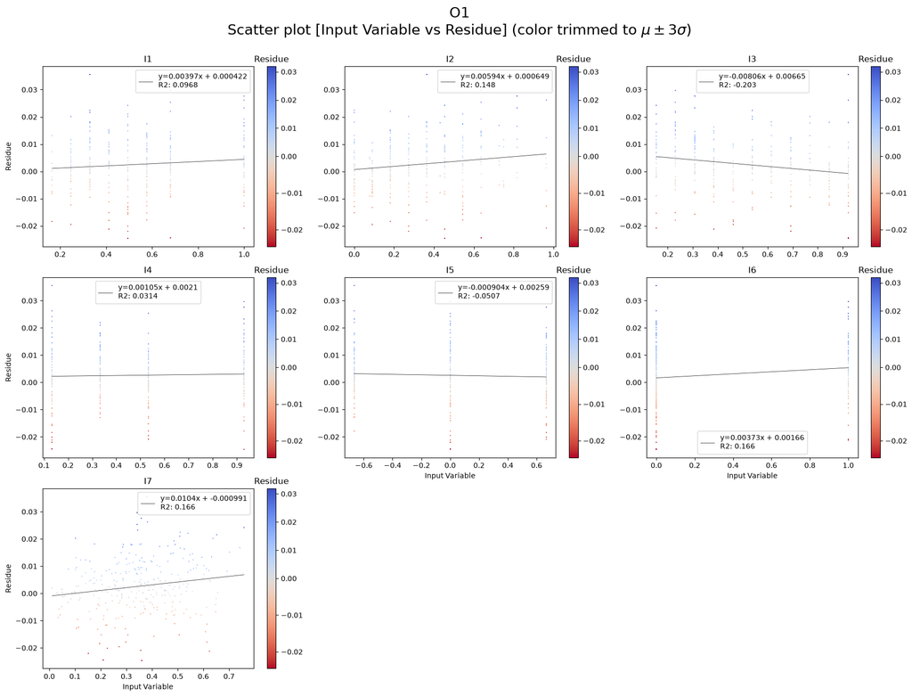

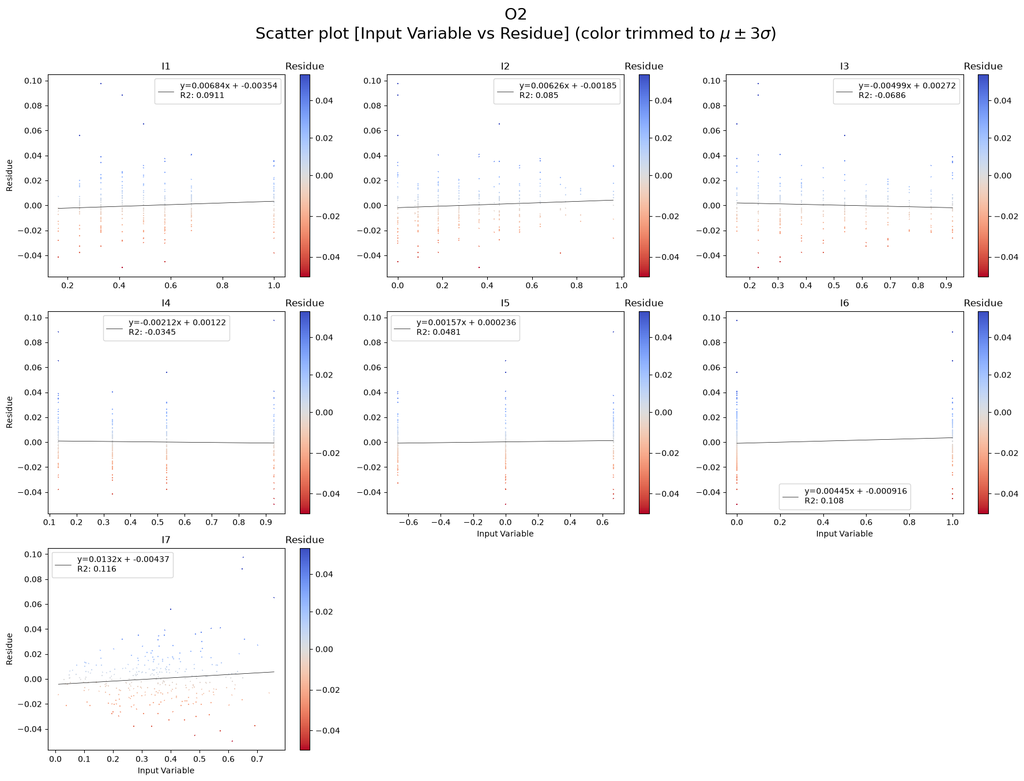

```python
for i, out_var in enumerate(output_names):
    validationlib.plots.scatterplot(
        x_test_df,
        residue_metric(yt_test_df, yh_test_df)[[out_var]],
        c=residue_metric(yt_test_df, yh_test_df)[[out_var]],
        correlationAxis="fit",
        xlabel="Input Variable",
        ylabel=residue_metric.name,
        title_prefix=yt_test_df.columns[i],
        trimStds=3,
        clabel=residue_metric.name,
        multiPlotsKwargs = {'tight_layout': True}
    )
    plt.show()
```

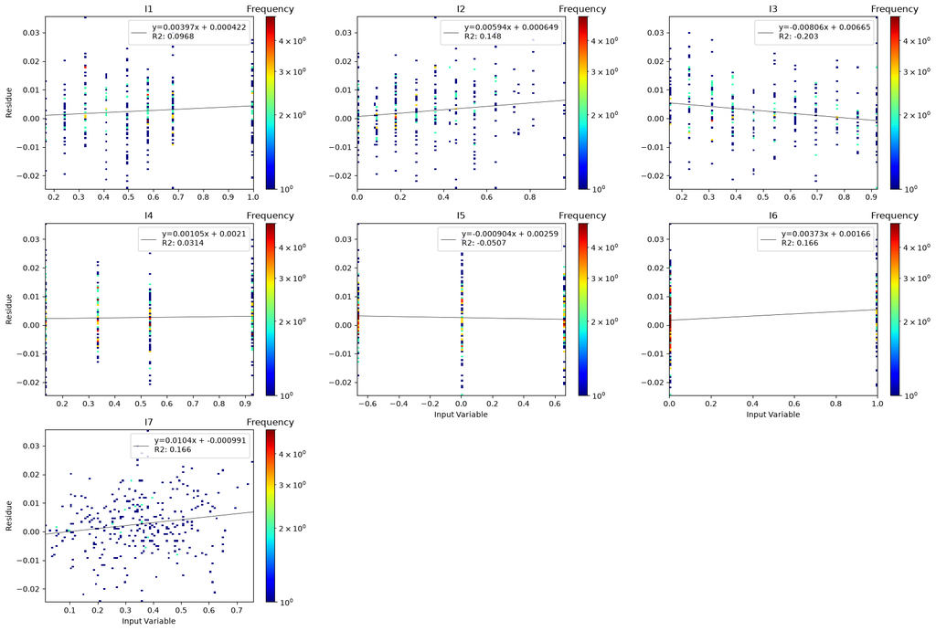

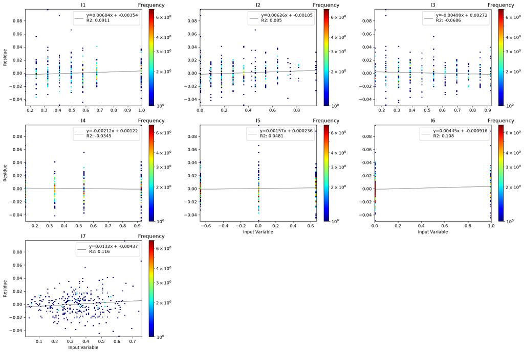

```python
for i, out_var in enumerate(output_names):
    validationlib.plots.hist2D(
        x_test_df,
        pd.concat([residue_metric(yt_test_df, yh_test_df)[[out_var]]]*len(input_names), axis=1),
        bins=100,
        xlabel="Input Variable",
        ylabel=residue_metric.name,
        scale="frequency",
        correlationAxis="fit",
        logscale=True,
        figHsize=21,
        figAspectRatio=4.5
    )
    plt.show()
```

```python
display(Markdown("""##### Detection of trends in the **residue** metric against each numerical variable
This returns a table for each **input** variable, containing:
- The correlation coefficient
- The p-value of the trend test. The lower the p-value, the stronger the evidence against the null hypothesis that there is no trend.
- If we are testing for a linear trend (Pearson coefficient), it is also displayed the normalized slope of the linear trend. The higher the slope, the stronger the linear trend. Since it is normalized, the slope comprises the range -1 to 1.
"""))

display(Markdown("Pearson coefficient"))
lintrend_tables = validationlib.tests.bias.trend_table(x_test_df, residue_metric(yt_test_df, yh_test_df))
for table in lintrend_tables:
    display(table)

display(Markdown("Spearman coefficient"))
lintrend_tables = validationlib.tests.bias.trend_table(x_test_df, residue_metric(yt_test_df, yh_test_df), method="spearman")
for table in lintrend_tables:
    display(table)
```

Detection of trends in the **residue** metric against each numerical variable

This returns a table for each **input** variable, containing:

- The correlation coefficient

- The p-value of the trend test. The lower the p-value, the stronger the evidence against the null hypothesis that there is no trend.

- If we are testing for a linear trend (Pearson coefficient), it is also displayed the normalized slope of the linear trend. The higher the slope, the stronger the linear trend. Since it is normalized, the slope comprises the range -1 to 1.

Pearson coefficient

O1

|  | I1 | I2 | I3 | I4 | I5 | I6 | I7 |
| --- | --- | --- | --- | --- | --- | --- | --- |
| Pearson coeff. | 0.096812 | 0.147508 | -0.202930 | 0.031413 | -0.050654 | 0.165911 | 0.166157 |
| p-value | 0.094177 | 0.010520 | 0.000405 | 0.587853 | 0.381978 | 0.003956 | 0.003902 |
| Slope (normalized) | 0.055163 | 0.095074 | -0.103117 | 0.013960 | -0.020043 | 0.062057 | 0.128846 |

O2

|  | I1 | I2 | I3 | I4 | I5 | I6 | I7 |
| --- | --- | --- | --- | --- | --- | --- | --- |
| Pearson coeff. | 0.091057 | 0.085043 | -0.068634 | -0.034458 | 0.048135 | 0.108084 | 0.115782 |
| p-value | 0.115523 | 0.141698 | 0.235936 | 0.552169 | 0.406125 | 0.061521 | 0.045093 |
| Slope (normalized) | 0.038778 | 0.040967 | -0.026066 | -0.011445 | 0.014235 | 0.030215 | 0.067104 |

Spearman coefficient

O1

|  | I1 | I2 | I3 | I4 | I5 | I6 | I7 |
| --- | --- | --- | --- | --- | --- | --- | --- |
| Spearman coeff. | 0.088569 | 0.181595 | -0.231915 | 0.010804 | -0.039260 | 0.170893 | 0.151269 |
| p-value | 0.125851 | 0.001586 | 0.000050 | 0.852166 | 0.498132 | 0.002983 | 0.008684 |

O2

|  | I1 | I2 | I3 | I4 | I5 | I6 | I7 |
| --- | --- | --- | --- | --- | --- | --- | --- |
| Spearman coeff. | 0.117101 | 0.130876 | -0.054904 | -0.035579 | 0.082971 | 0.114253 | 0.047700 |
| p-value | 0.042687 | 0.023382 | 0.343273 | 0.539298 | 0.151695 | 0.048026 | 0.410390 |

To further study P(E|X), we bin each variable. The number of bins is determined by the Sturges rule.

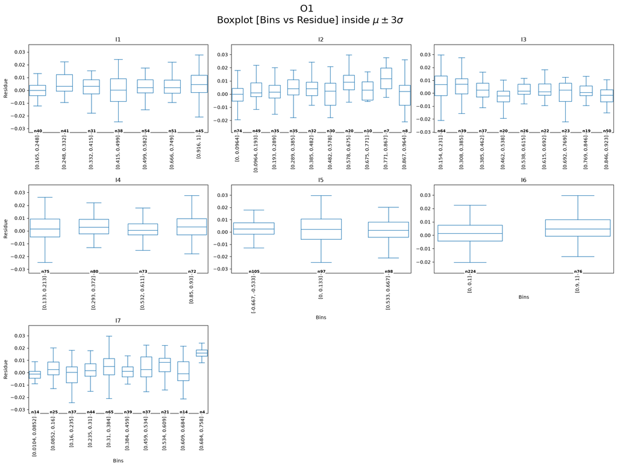

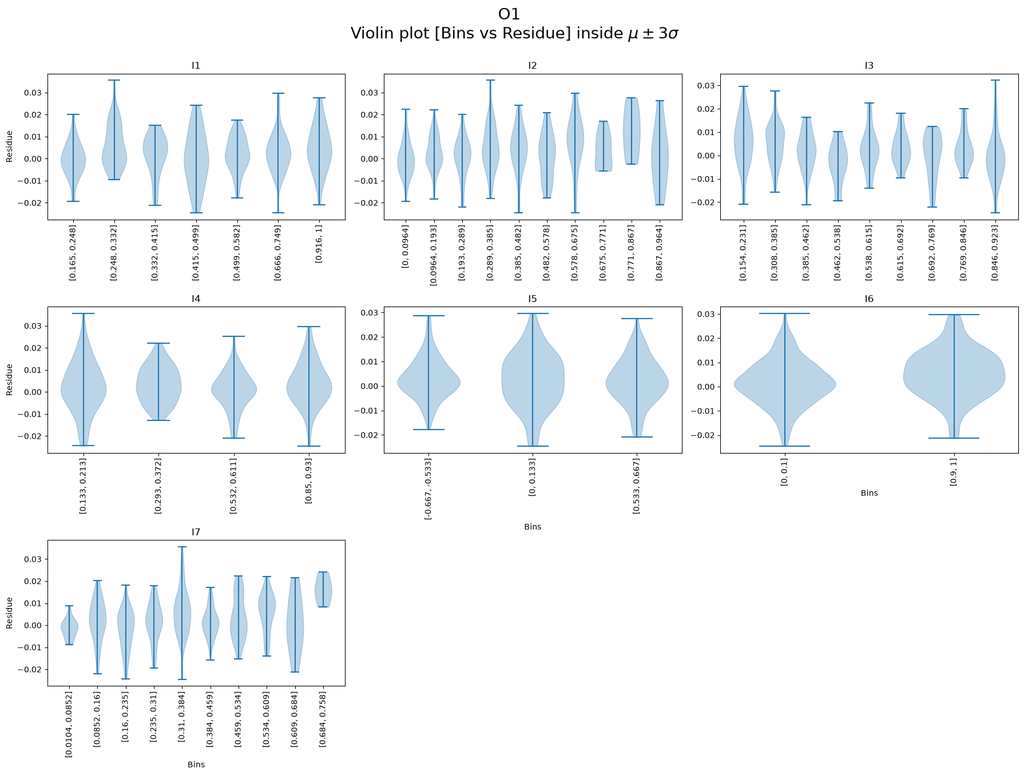

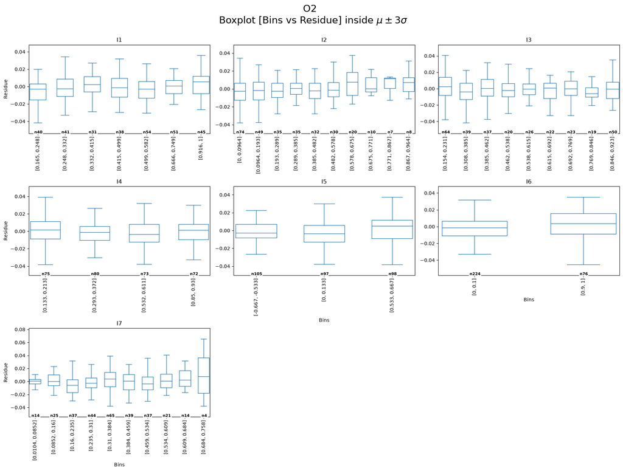

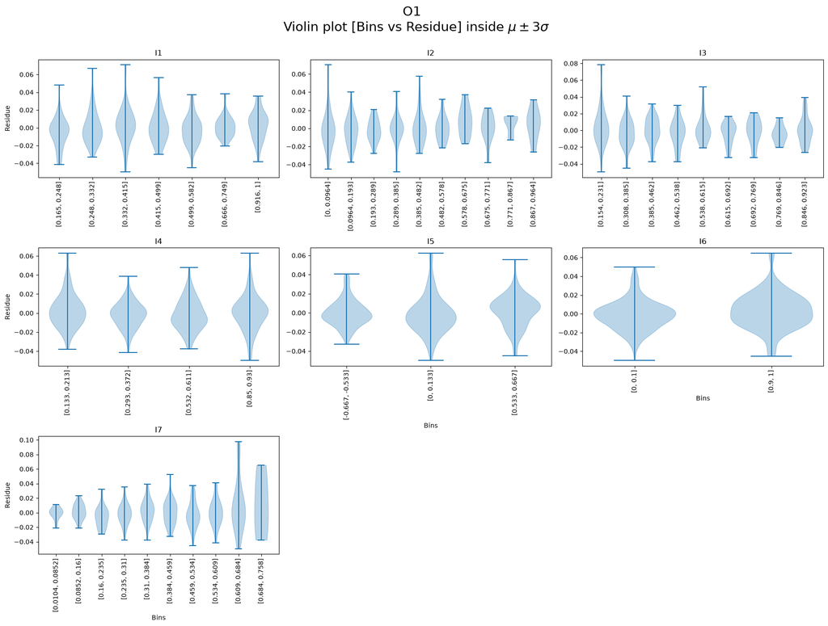

```python
for i, out_var in enumerate(output_names):
    validationlib.plots.boxplot(
        x_test_df,
        residue_metric(yt_test_df, yh_test_df)[[out_var]],
        bins = "sturges", # Number of bins for discretization. These bins are equally spaced between the minimum and maximum values of the numerical variable
        var_y = yt_test_df.columns[i], # Name of the output variable
        xlabel = 'Bins',
        ylabel = residue_metric.name,
        showfliers = False,
        trimStds=3,
        multiPlotsKwargs = {'tight_layout': True}
    )
    plt.show()

    # Violin plot of the metric against each numerical variable
    validationlib.plots.violinPlot(
        x_test_df,
        residue_metric(yt_test_df, yh_test_df)[[out_var]],
        bins = "sturges", # Number of bins for discretization. These bins are equally spaced between the minimum and maximum values of the numerical variable
        var_y = yt_test_df.columns[0], # Name of the output variable
        xlabel = 'Bins',
        ylabel = residue_metric.name,
        showextrema = True,
        trimStds=3,
        multiPlotsKwargs = {'tight_layout': True}
    )
    plt.show()
```

We can perform some hypothesis test on the obtained bins to check if they present biases. Specifically, these tests are:

- Levene. Null hyp. $\rightarrow$ all bins have the same variance.
- ANOVA: Null hyp. $\rightarrow$ all bins have the same mean. (*NOTE: In order to have valid ANOVA results, the repective bins must be homocedastic and normally distributed. If these requirements are not fulfilled, ANOVA results are shown as `nan`*).
- Kruskall-Wallis: Null hyp. $\rightarrow$ all bins come from the same distribution.

```python
# Create an auxiliary dataframe with the binned numerical variables
# This allows to use the tests and plots for categorical variables with numerical variables
df_binned = pd.DataFrame(index=x_test_df.index)
for i, in_var in enumerate(input_names):
    _, df_binned[in_var+"_binned"] = validationlib.misc.subsampling.bin_data(x_test_df[in_var], bins="sturges")

num_binned_vars = df_binned.columns
df_binned = df_binned.join(residue_metric(yt_test_df, yh_test_df))
```

```python
output_dict = validationlib.tests.bias.parametric_bias_quantification_pipeline(
    df_binned,
    num_binned_vars,
    yt_test_df.columns,
)

for key, val in output_dict.items():
    if val != []:
        display(val)
```

Levene test (p-value)

|  | O1 | O2 |
| --- | --- | --- |
| I1_binned | 0.03992 | 0.47368 |
| I2_binned | 0.30134 | 0.40323 |
| I3_binned | 0.58456 | 0.24330 |
| I4_binned | 0.04656 | 0.23306 |
| I5_binned | 0.00386 | 0.06539 |
| I6_binned | 0.43425 | 0.08543 |
| I7_binned | 0.03119 | 0.00001 |

Normality test (# of bins with p-value over 0.05)

|  | O1 | O2 |
| --- | --- | --- |
| I1_binned | 7/7 | 2/7 |
| I2_binned | 7/10 | 4/10 |
| I3_binned | 7/9 | 6/9 |
| I4_binned | 4/4 | 1/4 |
| I5_binned | 2/3 | 0/3 |
| I6_binned | 2/2 | 0/2 |
| I7_binned | 7/10 | 7/10 |

1-way ANOVA (p-value)

|  | O1 | O2 |
| --- | --- | --- |
| I1_binned | nan | nan |
| I2_binned | nan | nan |
| I3_binned | nan | nan |
| I4_binned | nan | nan |
| I5_binned | nan | nan |
| I6_binned | 0.00396 | nan |
| I7_binned | nan | nan |

```
[     N      mean  Z score  Bias
 0  224  0.001656      1.0  Weak
 9   76  0.005390      1.0  Weak]
```

```
[     N       var  Z score  Bias
 0  224  0.000091      1.0     -
 9   76  0.000101      1.0  Weak]
```

```python
table = validationlib.tests.bias.bias_detection_table(
    df_binned,
    num_binned_vars,
    yt_test_df.columns,
    method="kruskal"
)
display(table)
```

Kruskall-Wallis test (p-value)

|  | O1 | O2 |
| --- | --- | --- |
| I1_binned | 0.07394 | 0.18193 |
| I2_binned | 0.00581 | 0.35703 |
| I3_binned | 0.00101 | 0.60529 |
| I4_binned | 0.30835 | 0.32934 |
| I5_binned | 0.79244 | 0.03890 |
| I6_binned | 0.00313 | 0.04820 |
| I7_binned | 0.00075 | 0.24918 |

#### ABS. ERR.

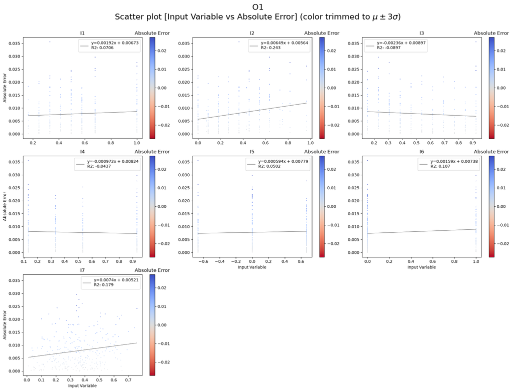

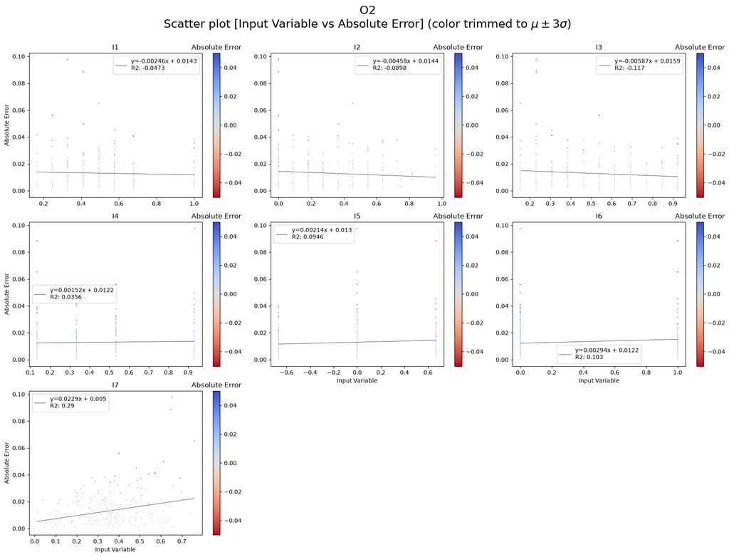

```python
for i, out_var in enumerate(output_names):
    validationlib.plots.scatterplot(
        x_test_df,
        abserr_metric(yt_test_df, yh_test_df)[[out_var]],
        c=abserr_metric(yt_test_df, yh_test_df)[[out_var]],
        correlationAxis="fit",
        xlabel="Input Variable",
        ylabel=abserr_metric.name,
        title_prefix=yt_test_df.columns[i],
        trimStds=3,
        clabel=abserr_metric.name,
        multiPlotsKwargs = {'tight_layout': True}
    )
    plt.show()
```

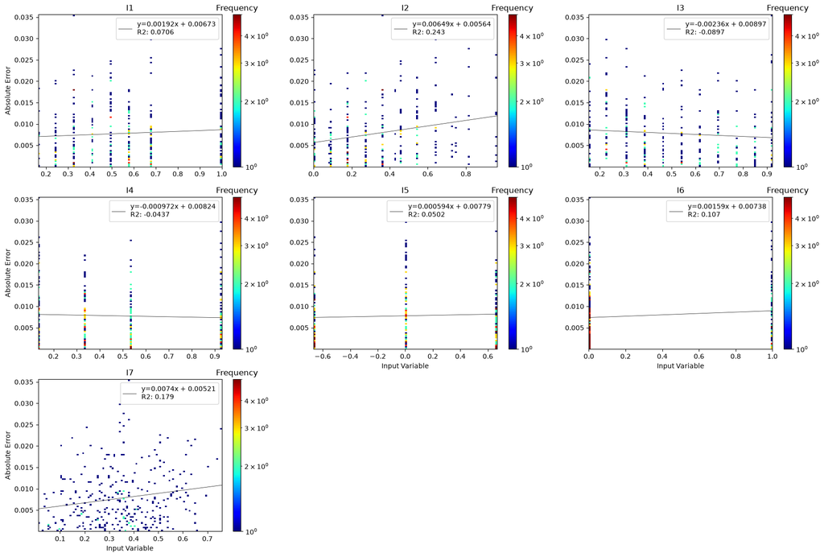

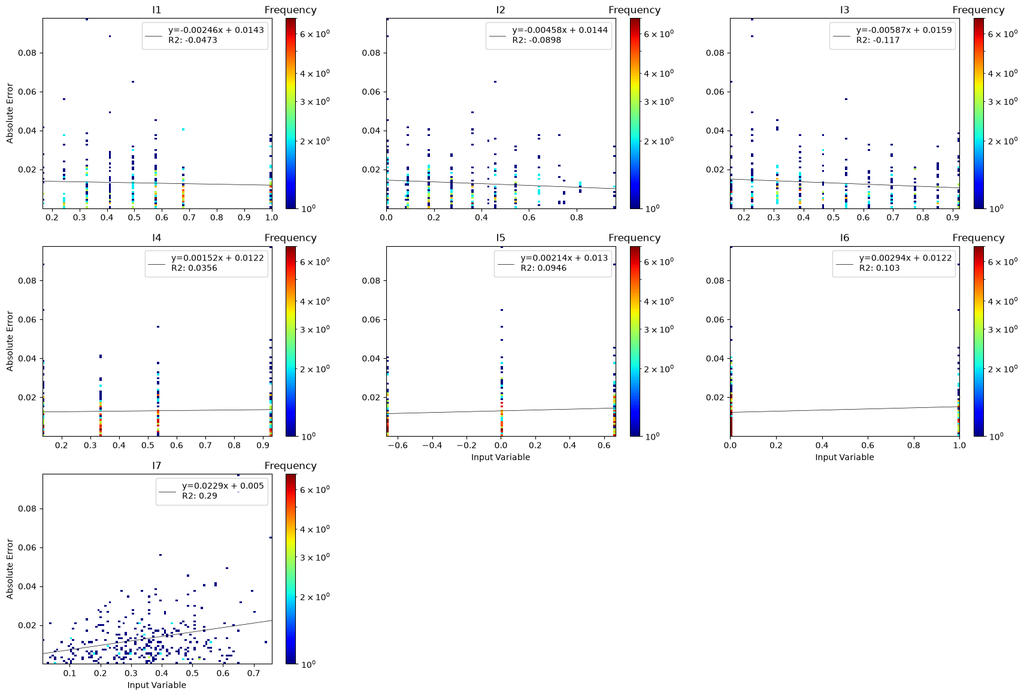

```python
for i, out_var in enumerate(output_names):
    validationlib.plots.hist2D(
        x_test_df,
        pd.concat([abserr_metric(yt_test_df, yh_test_df)[[out_var]]]*len(input_names), axis=1),
        bins=100,
        xlabel="Input Variable",
        ylabel=abserr_metric.name,
        scale="frequency",
        correlationAxis="fit",
        logscale=True,
        figHsize=21,
        figAspectRatio=4.5
    )
    plt.show()
```

```python
display(Markdown("""##### Detection of trends in the **absolute error** metric against each numerical variable
This returns a table for each **input** variable, containing:
- The correlation coefficient
- The p-value of the trend test. The lower the p-value, the stronger the evidence against the null hypothesis that there is no trend.
- If we are testing for a linear trend (Pearson coefficient), it is also displayed the normalized slope of the linear trend. The higher the slope, the stronger the linear trend. Since it is normalized, the slope comprises the range -1 to 1.
"""))

display(Markdown("Pearson coefficient"))
lintrend_tables = validationlib.tests.bias.trend_table(x_test_df, abserr_metric(yt_test_df, yh_test_df))
for table in lintrend_tables:
    display(table)

display(Markdown("Spearman coefficient"))
lintrend_tables = validationlib.tests.bias.trend_table(x_test_df, abserr_metric(yt_test_df, yh_test_df), method="spearman")
for table in lintrend_tables:
    display(table)
```

Detection of trends in the **absolute error** metric against each numerical variable

This returns a table for each **input** variable, containing:

- The correlation coefficient

- The p-value of the trend test. The lower the p-value, the stronger the evidence against the null hypothesis that there is no trend.

- If we are testing for a linear trend (Pearson coefficient), it is also displayed the normalized slope of the linear trend. The higher the slope, the stronger the linear trend. Since it is normalized, the slope comprises the range -1 to 1.

Pearson coefficient

O1

|  | I1 | I2 | I3 | I4 | I5 | I6 | I7 |
| --- | --- | --- | --- | --- | --- | --- | --- |
| Pearson coeff. | 0.070625 | 0.243419 | -0.089694 | -0.043720 | 0.050242 | 0.106725 | 0.179146 |
| p-value | 0.222587 | 0.000020 | 0.121099 | 0.450582 | 0.385873 | 0.064878 | 0.001838 |
| Slope (normalized) | 0.045090 | 0.175793 | -0.051068 | -0.021769 | 0.022275 | 0.044729 | 0.155654 |

O2

|  | I1 | I2 | I3 | I4 | I5 | I6 | I7 |
| --- | --- | --- | --- | --- | --- | --- | --- |
| Pearson coeff. | -0.047320 | -0.089803 | -0.116685 | 0.035642 | 0.094560 | 0.103045 | 0.289617 |
| p-value | 0.414135 | 0.120642 | 0.043434 | 0.538586 | 0.102120 | 0.074734 | 0.000000 |
| Slope (normalized) | -0.021041 | -0.045170 | -0.046271 | 0.012360 | 0.029199 | 0.030078 | 0.175261 |

Spearman coefficient

O1

|  | I1 | I2 | I3 | I4 | I5 | I6 | I7 |
| --- | --- | --- | --- | --- | --- | --- | --- |
| Spearman coeff. | 0.050337 | 0.225925 | -0.128411 | -0.068900 | 0.060418 | 0.098588 | 0.154173 |
| p-value | 0.384969 | 0.000079 | 0.026144 | 0.234122 | 0.296927 | 0.088264 | 0.007468 |

O2

|  | I1 | I2 | I3 | I4 | I5 | I6 | I7 |
| --- | --- | --- | --- | --- | --- | --- | --- |
| Spearman coeff. | 0.001804 | -0.042761 | -0.100063 | 0.019886 | 0.114519 | 0.117881 | 0.201148 |
| p-value | 0.975182 | 0.460584 | 0.083585 | 0.731581 | 0.047504 | 0.041314 | 0.000456 |

To further study P(E|X), we bin each variable. The number of bins is determined by the Sturges rule.

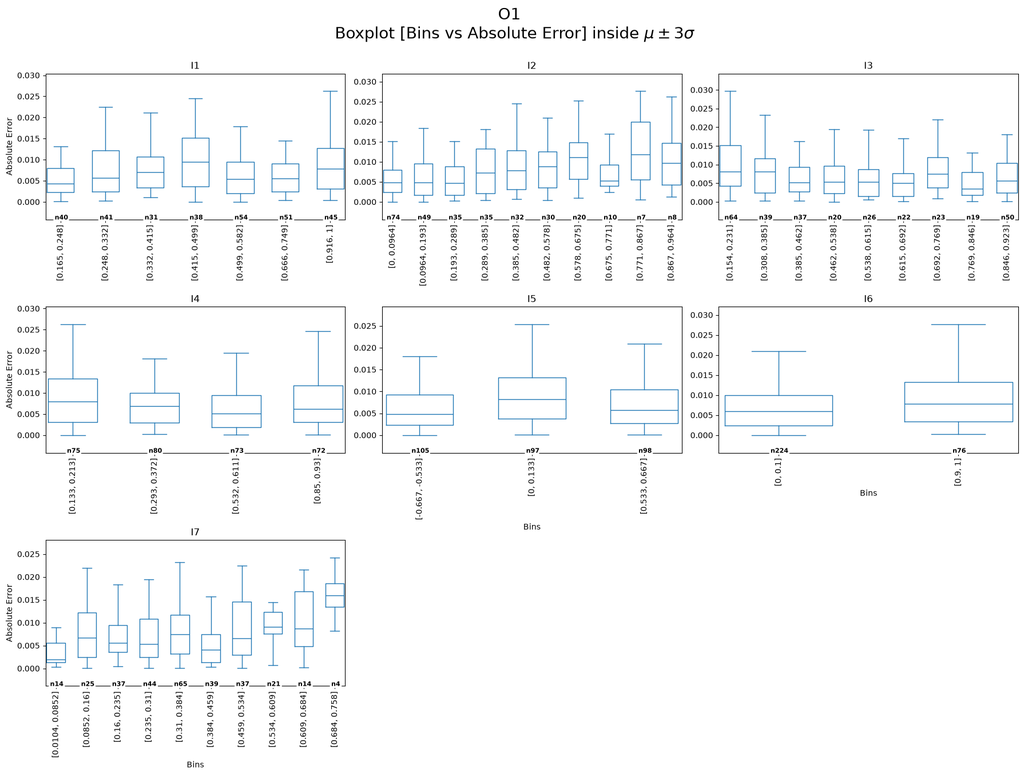

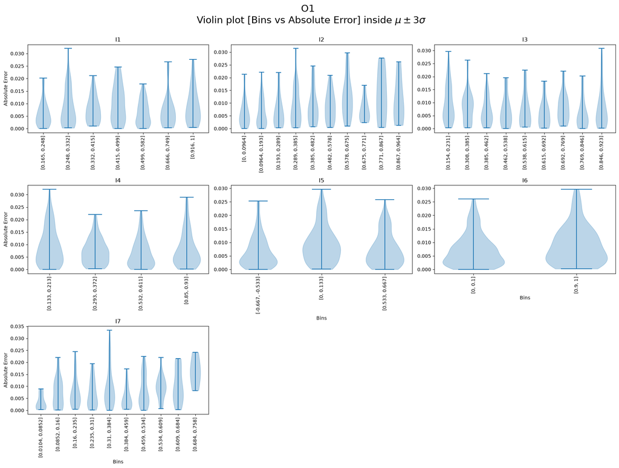

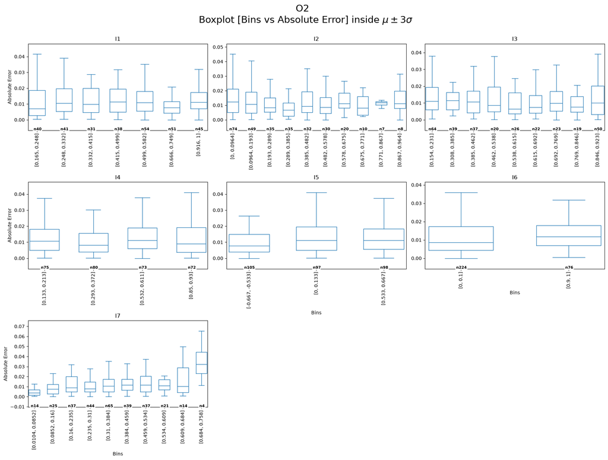

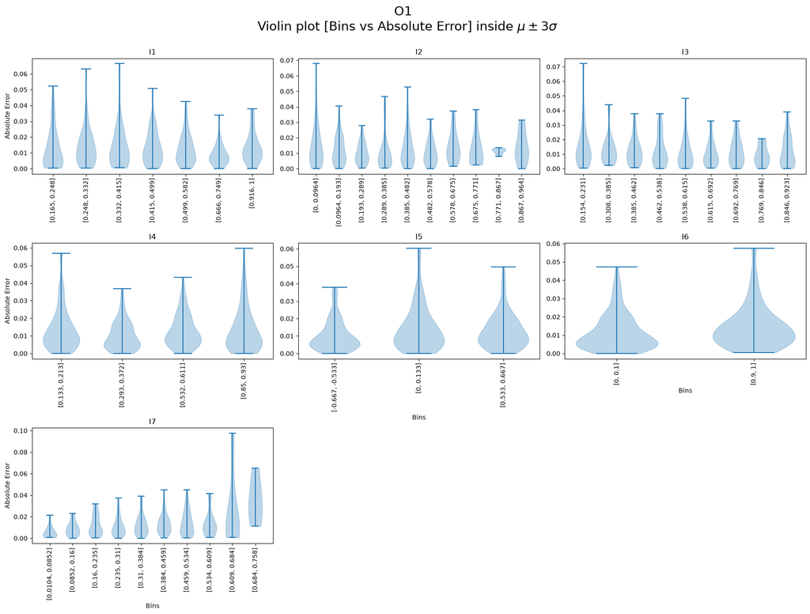

```python
for i, out_var in enumerate(output_names):
    validationlib.plots.boxplot(
        x_test_df,
        abserr_metric(yt_test_df, yh_test_df)[[out_var]],
        bins = "sturges", # Number of bins for discretization. These bins are equally spaced between the minimum and maximum values of the numerical variable
        var_y = yt_test_df.columns[i], # Name of the output variable
        xlabel = 'Bins',
        ylabel = abserr_metric.name,
        showfliers = False,
        trimStds=3,
        multiPlotsKwargs = {'tight_layout': True}
    )
    plt.show()

    # Violin plot of the metric against each numerical variable
    validationlib.plots.violinPlot(
        x_test_df,
        abserr_metric(yt_test_df, yh_test_df)[[out_var]],
        bins = "sturges", # Number of bins for discretization. These bins are equally spaced between the minimum and maximum values of the numerical variable
        var_y = yt_test_df.columns[0], # Name of the output variable
        xlabel = 'Bins',
        ylabel = abserr_metric.name,
        showextrema = True,
        trimStds=3,
        multiPlotsKwargs = {'tight_layout': True}
    )
    plt.show()
```

We can perform some hypothesis test on the obtained bins to check if they present biases. Specifically, these tests are:

- Levene. Null hyp. $\rightarrow$ all bins have the same variance.
- ANOVA: Null hyp. $\rightarrow$ all bins have the same mean. (*NOTE: In order to have valid ANOVA results, the repective bins must be homocedastic and normally distributed. If these requirements are not fulfilled, ANOVA results are shown as `nan`*).
- Kruskall-Wallis: Null hyp. $\rightarrow$ all bins come from the same distribution.

```python
df_binned = pd.DataFrame(index=x_test_df.index)
for i, in_var in enumerate(input_names):
    _, df_binned[in_var+"_binned"] = validationlib.misc.subsampling.bin_data(x_test_df[in_var], bins="sturges")

num_binned_vars = df_binned.columns
df_binned = df_binned.join(abserr_metric(yt_test_df, yh_test_df))
```

```python
output_dict = validationlib.tests.bias.parametric_bias_quantification_pipeline(
    df_binned,
    num_binned_vars,
    yt_test_df.columns,
)

for key, val in output_dict.items():
    if val != []:
        display(val)
```

Levene test (p-value)

|  | O1 | O2 |
| --- | --- | --- |
| I1_binned | 0.04521 | 0.21463 |
| I2_binned | 0.03890 | 0.11435 |
| I3_binned | 0.55306 | 0.34596 |
| I4_binned | 0.02579 | 0.18911 |
| I5_binned | 0.46326 | 0.04946 |
| I6_binned | 0.14256 | 0.48171 |
| I7_binned | 0.06889 | 0.00003 |

Normality test (# of bins with p-value over 0.05)

|  | O1 | O2 |
| --- | --- | --- |
| I1_binned | 4/7 | 0/7 |
| I2_binned | 3/10 | 2/10 |
| I3_binned | 6/9 | 3/9 |
| I4_binned | 0/4 | 0/4 |
| I5_binned | 0/3 | 0/3 |
| I6_binned | 0/2 | 0/2 |
| I7_binned | 4/10 | 3/10 |

1-way ANOVA (p-value)

|  | O1 | O2 |
| --- | --- | --- |
| I1_binned | nan | nan |
| I2_binned | nan | nan |
| I3_binned | nan | nan |
| I4_binned | nan | nan |
| I5_binned | nan | nan |
| I6_binned | nan | nan |
| I7_binned | nan | nan |

```python
table = validationlib.tests.bias.bias_detection_table(
    df_binned,
    num_binned_vars,
    yt_test_df.columns,
    method="kruskal"
)
display(table)
```

Kruskall-Wallis test (p-value)

|  | O1 | O2 |
| --- | --- | --- |
| I1_binned | 0.10496 | 0.35992 |
| I2_binned | 0.01282 | 0.50033 |
| I3_binned | 0.09979 | 0.66190 |
| I4_binned | 0.15603 | 0.21948 |
| I5_binned | 0.00507 | 0.06860 |
| I6_binned | 0.08824 | 0.04151 |
| I7_binned | 0.00150 | 0.01427 |

```python
if len(splitting_variables) == 2:
    display(Markdown("Since the splitting is done by two variables, we also show the error conditioned to the splitting variables"))

    for out_var in output_names:
        grouped_df = pd.concat([x_test_df[splitting_variables], abserr_metric(yt_test_df, yh_test_df)], axis=1).groupby(splitting_variables)
        mean_error = grouped_df.mean().reset_index()
        q95_error = grouped_df.quantile(0.95).reset_index()
        fig, axs = plt.subplots(1, 2, figsize=(12, 6))
        h = axs[0].scatter(mean_error[splitting_variables[0]], mean_error[splitting_variables[1]], c=mean_error[out_var], cmap="viridis", s=100)
        plt.colorbar(h, ax=axs[0], label="Mean of " + abserr_metric.name)
        axs[0].set_xlabel(splitting_variables[0])
        axs[0].set_ylabel(splitting_variables[1])

        h = axs[1].scatter(q95_error[splitting_variables[0]], q95_error[splitting_variables[1]], c=q95_error[out_var], cmap="viridis", s=100)
        plt.colorbar(h, ax=axs[1], label="95th percentile of " + abserr_metric.name)
        axs[1].set_xlabel(splitting_variables[0])
        axs[1].set_ylabel(splitting_variables[1])

        fig.suptitle(f"Error conditioned to the splitting variables for output variable {out_var}")

        plt.tight_layout()
        plt.show()
```

### P(E|Y)

Here we study the distribution of the error conditioned to the output of the model

#### RESIDUE

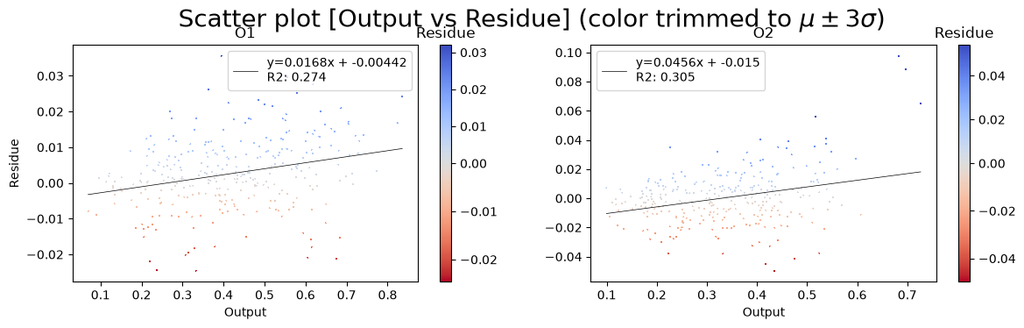

```python
validationlib.plots.scatterplot(
    yt_test_df,
    residue_metric(yt_test_df, yh_test_df),
    c=residue_metric(yt_test_df, yh_test_df),
    clabel=residue_metric.name,
    correlationAxis="fit",
    xlabel="Output",
    ylabel=residue_metric.name,
    trimStds=3,
    cmapCenter=residue_metric.neutral
)
plt.show()
```

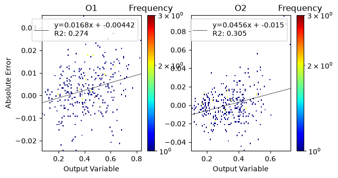

```python
validationlib.plots.hist2D(
    yt_test_df,
    residue_metric(yt_test_df, yh_test_df),
    bins=100,
    xlabel="Output Variable",
    ylabel=abserr_metric.name,
    scale="frequency",
    correlationAxis="fit",
    logscale=True,
    figHsize=7,
    figAspectRatio=2
)
plt.show()
```

```python
display(Markdown("""##### Detection of trends in the **residue** metric against each numerical variable
This returns a table for each **output** variable, containing:
- The correlation coefficient
- The p-value of the trend test. The lower the p-value, the stronger the evidence against the null hypothesis that there is no trend.
- If we are testing for a linear trend (Pearson coefficient), it is also displayed the normalized slope of the linear trend. The higher the slope, the stronger the linear trend. Since it is normalized, the slope comprises the range -1 to 1.
"""))

display(Markdown("Pearson coefficient"))
lintrend_tables = validationlib.tests.bias.trend_table(yt_test_df, residue_metric(yt_test_df, yh_test_df))
for table in lintrend_tables:
    display(table)

display(Markdown("Spearman coefficient"))
lintrend_tables = validationlib.tests.bias.trend_table(yt_test_df, residue_metric(yt_test_df, yh_test_df), method="spearman")
for table in lintrend_tables:
    display(table)
```

Detection of trends in the **residue** metric against each numerical variable

This returns a table for each **output** variable, containing:

- The correlation coefficient

- The p-value of the trend test. The lower the p-value, the stronger the evidence against the null hypothesis that there is no trend.

- If we are testing for a linear trend (Pearson coefficient), it is also displayed the normalized slope of the linear trend. The higher the slope, the stronger the linear trend. Since it is normalized, the slope comprises the range -1 to 1.

Pearson coefficient

O1

|  | O1 | O2 |
| --- | --- | --- |
| Pearson coeff. | 0.273588 | 0.163879 |
| p-value | 0.000002 | 0.004429 |
| Slope (normalized) | 0.214154 | 0.139496 |

O2

|  | O1 | O2 |
| --- | --- | --- |
| Pearson coeff. | 0.140155 | 0.304977 |
| p-value | 0.015123 | 0.000000 |
| Slope (normalized) | 0.081995 | 0.194024 |

Spearman coefficient

O1

|  | O1 | O2 |
| --- | --- | --- |
| Spearman coeff. | 0.277895 | 0.131847 |
| p-value | 0.000001 | 0.022365 |

O2

|  | O1 | O2 |
| --- | --- | --- |
| Spearman coeff. | 0.128198 | 0.191976 |
| p-value | 0.026395 | 0.000831 |

To further study P(E|Y), we bin each output variable. The number of bins is determined by the Sturges rule.

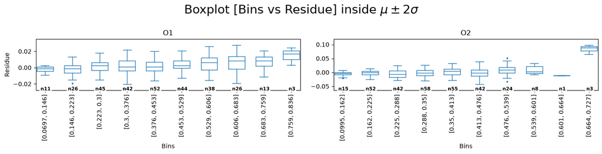

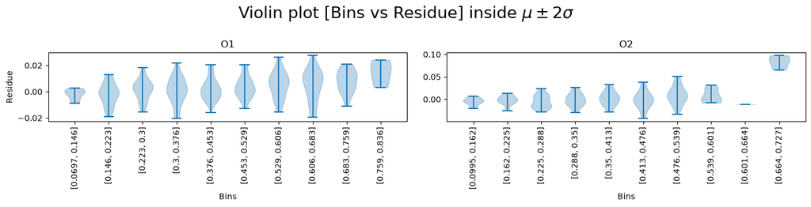

```python
validationlib.plots.boxplot(
    yt_test_df,
    residue_metric(yt_test_df, yh_test_df),
    bins = "sturges",
    xlabel = 'Bins',
    ylabel = residue_metric.name,
    showfliers = True,
    trimStds=2,
    multiPlotsKwargs = {'tight_layout': True}
)
plt.show()

validationlib.plots.violinPlot(
    yt_test_df,
    residue_metric(yt_test_df, yh_test_df),
    bins = "sturges",
    xlabel = 'Bins',
    ylabel = residue_metric.name,
    showextrema = True,
    trimStds=2,
    multiPlotsKwargs = {'tight_layout': True}
)
plt.show()
```

We can perform some hypothesis test on the obtained bins to check if they present biases. Specifically, these tests are:

- Levene. Null hyp. $\rightarrow$ all bins have the same variance.
- ANOVA: Null hyp. $\rightarrow$ all bins have the same mean. (*NOTE: In order to have valid ANOVA results, the repective bins must be homocedastic and normally distributed. If these requirements are not fulfilled, ANOVA results are shown as `nan`*).
- Kruskall-Wallis: Null hyp. $\rightarrow$ all bins come from the same distribution.

```python
df_binned = pd.DataFrame(index=yt_test_df.index)
for i, out_var in enumerate(yt_test_df.columns):
    _, df_binned[out_var+"_binned"] = validationlib.misc.subsampling.bin_data(yt_test_df[out_var], bins="sturges")

num_binned_outputs = df_binned.columns
df_binned = df_binned.join(residue_metric(yt_test_df, yh_test_df))
```

```python
bias_quantification_output = validationlib.tests.bias.parametric_bias_quantification_pipeline(
    df_binned,
    num_binned_outputs,
    yt_test_df.columns,
    alpha=0.05,
    min_bin_size=20,
    min_normal_proportion=0.9,
    colorPair=['green', 'red'],
    cmap="viridis"
)

for key, value in bias_quantification_output.items():
    if isinstance(value, list):
        for i, table in enumerate(value):
            display(table.transpose())
    else:
        display(value)
```

Levene test (p-value)

|  | O1 | O2 |
| --- | --- | --- |
| O1_binned | 0.19425 | 0.10522 |
| O2_binned | 0.04035 | 0.00430 |

Normality test (# of bins with p-value over 0.05)

|  | O1 | O2 |
| --- | --- | --- |
| O1_binned | 6/10 | 4/10 |
| O2_binned | 4/10 | 5/10 |

1-way ANOVA (p-value)

|  | O1 | O2 |
| --- | --- | --- |
| O1_binned | nan | nan |
| O2_binned | nan | nan |

```python
table = validationlib.tests.bias.bias_detection_table(
    df_binned,
    num_binned_outputs,
    yt_test_df.columns,
    method="kruskal"
)
display(table)
```

Kruskall-Wallis test (p-value)

|  | O1 | O2 |
| --- | --- | --- |
| O1_binned | 0.00257 | 0.50123 |
| O2_binned | 0.10493 | 0.00224 |

#### ABS. ERR.

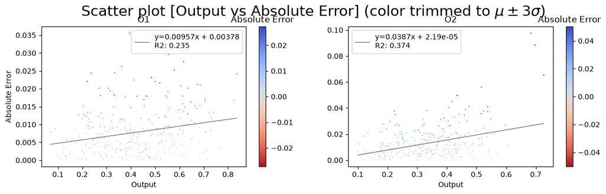

```python
validationlib.plots.scatterplot(
    yt_test_df,
    abserr_metric(yt_test_df, yh_test_df),
    c=abserr_metric(yt_test_df, yh_test_df),
    clabel=abserr_metric.name,
    correlationAxis="fit",
    xlabel="Output",
    ylabel=abserr_metric.name,
    trimStds=3,
    cmapCenter=abserr_metric.neutral
)
plt.show()
```

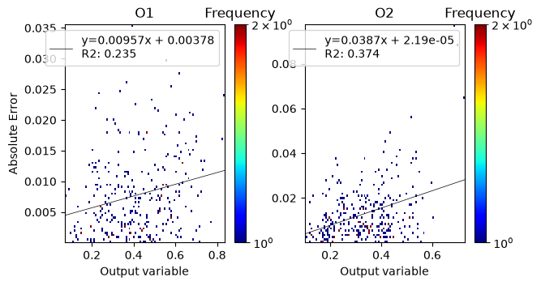

```python
validationlib.plots.hist2D(
    yt_test_df,
    abserr_metric(yt_test_df, yh_test_df),
    bins=100,
    xlabel="Output variable",
    ylabel=abserr_metric.name,
    correlationAxis="fit",
    scale="frequency",
    logscale=True,
    figHsize=7,
    figAspectRatio=2
)
plt.show()
```

```python
display(Markdown("""##### Detection of trends in the **absolute error** metric against each numerical variable
This returns a table for each **output** variable, containing:
- The correlation coefficient
- The p-value of the trend test. The lower the p-value, the stronger the evidence against the null hypothesis that there is no trend.
- If we are testing for a linear trend (Pearson coefficient), it is also displayed the normalized slope of the linear trend. The higher the slope, the stronger the linear trend. Since it is normalized, the slope comprises the range -1 to 1.
"""))

display(Markdown("Pearson coefficient"))
lintrend_tables = validationlib.tests.bias.trend_table(yt_test_df, abserr_metric(yt_test_df, yh_test_df))
for table in lintrend_tables:
    display(table)

display(Markdown("Spearman coefficient"))
lintrend_tables = validationlib.tests.bias.trend_table(yt_test_df, abserr_metric(yt_test_df, yh_test_df), method="spearman")
for table in lintrend_tables:
    display(table)
```

Detection of trends in the **absolute error** metric against each numerical variable

This returns a table for each **output** variable, containing:

- The correlation coefficient

- The p-value of the trend test. The lower the p-value, the stronger the evidence against the null hypothesis that there is no trend.

- If we are testing for a linear trend (Pearson coefficient), it is also displayed the normalized slope of the linear trend. The higher the slope, the stronger the linear trend. Since it is normalized, the slope comprises the range -1 to 1.

Pearson coefficient

O1

|  | O1 | O2 |
| --- | --- | --- |
| Pearson coeff. | 0.234982 | 0.222153 |
| p-value | 0.000039 | 0.000104 |
| Slope (normalized) | 0.206095 | 0.211880 |

O2

|  | O1 | O2 |
| --- | --- | --- |
| Pearson coeff. | 0.179049 | 0.373952 |
| p-value | 0.001849 | 0.000000 |
| Slope (normalized) | 0.109373 | 0.248406 |

Spearman coefficient

O1

|  | O1 | O2 |
| --- | --- | --- |
| Spearman coeff. | 0.221690 | 0.189856 |
| p-value | 0.000108 | 0.000950 |

O2

|  | O1 | O2 |
| --- | --- | --- |
| Spearman coeff. | 0.151544 | 0.238921 |
| p-value | 0.008562 | 0.000029 |

To further study P(E|Y), we bin each variable. The number of bins is determined by the Sturges rule.

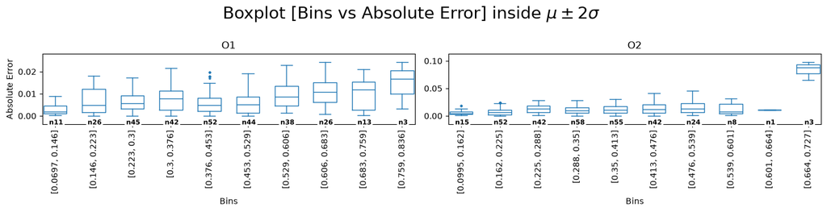

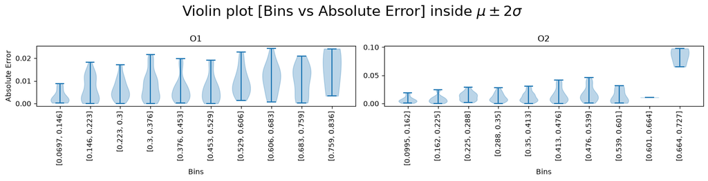

```python
validationlib.plots.boxplot(
    yt_test_df,
    abserr_metric(yt_test_df, yh_test_df),
    bins = "sturges",
    xlabel = 'Bins',
    ylabel = abserr_metric.name,
    showfliers = True,
    trimStds=2,
    multiPlotsKwargs = {'tight_layout': True}
)
plt.show()

validationlib.plots.violinPlot(
    yt_test_df,
    abserr_metric(yt_test_df, yh_test_df),
    bins = "sturges",
    xlabel = 'Bins',
    ylabel = abserr_metric.name,
    showextrema = True,
    trimStds=2,
    multiPlotsKwargs = {'tight_layout': True}
)
plt.show()
```

We can perform some hypothesis test on the obtained bins to check if they present biases. Specifically, these tests are:

- Levene. Null hyp. $\rightarrow$ all bins have the same variance.
- ANOVA: Null hyp. $\rightarrow$ all bins have the same mean. (*NOTE: In order to have valid ANOVA results, the repective bins must be homocedastic and normally distributed. If these requirements are not fulfilled, ANOVA results are shown as `nan`*).
- Kruskall-Wallis: Null hyp. $\rightarrow$ all bins come from the same distribution.

```python
df_binned = pd.DataFrame(index=yt_test_df.index)
for i, out_var in enumerate(yt_test_df.columns):
    _, df_binned[out_var+"_binned"] = validationlib.misc.subsampling.bin_data(yt_test_df[out_var], bins="sturges")

num_binned_outputs = df_binned.columns
df_binned = df_binned.join(abserr_metric(yt_test_df, yh_test_df))
```

```python
bias_quantification_output = validationlib.tests.bias.parametric_bias_quantification_pipeline(
    df_binned,
    num_binned_outputs,
    yt_test_df.columns,
    alpha=0.05,
    min_bin_size=20,
    min_normal_proportion=0.9,
    colorPair=['green', 'red'],
    cmap="viridis"
)

for key, value in bias_quantification_output.items():
    if isinstance(value, list):
        for i, table in enumerate(value):
            display(table.transpose())
    else:
        display(value)
```

Levene test (p-value)

|  | O1 | O2 |
| --- | --- | --- |
| O1_binned | 0.41794 | 0.34460 |
| O2_binned | 0.28983 | 0.00530 |

Normality test (# of bins with p-value over 0.05)

|  | O1 | O2 |
| --- | --- | --- |
| O1_binned | 2/10 | 3/10 |
| O2_binned | 1/10 | 2/10 |

1-way ANOVA (p-value)

|  | O1 | O2 |
| --- | --- | --- |
| O1_binned | nan | nan |
| O2_binned | nan | nan |

```python
table = validationlib.tests.bias.bias_detection_table(
    df_binned,
    num_binned_outputs,
    yt_test_df.columns,
    method="kruskal"
)
display(table)
```

Kruskall-Wallis test (p-value)

|  | O1 | O2 |
| --- | --- | --- |
| O1_binned | 0.00074 | 0.04151 |
| O2_binned | 0.00304 | 0.00033 |

## UNCERTAINTY

In this section we build global and local uncertainty models for the error of the model under study. These models would be used in the case of new (unseen) samples, giving an estimate of the model's error in the form of a confidence interval.

Uncertainty models are built from the validation split. These models, by construction, will provide a confidence interval for the model's error, and they will be tested in the test set (hold-out). An uncertainty model will be considered valid if the proportion of test points inside the predicted uncertainty interval (i.e., the coverage of the model) is close to the specified CI size during training.

```python
# Concat validation and test datasets for uncertainty models
from scipy.sparse import csr_matrix

yt_valtest_df = pd.concat([yt_val_df, yt_test_df], axis=0, ignore_index=True)
yh_valtest_df = pd.concat([yh_val_df, yh_test_df], axis=0, ignore_index=True)
x_valtest_df = pd.concat([x_val_df, x_test_df], axis=0, ignore_index=True)

val_mask = np.zeros(yt_valtest_df.shape, dtype=bool)
val_mask[:len(yt_val_df)] = True
val_mask = csr_matrix(val_mask)

test_mask = np.zeros(yt_valtest_df.shape, dtype=bool)
test_mask[len(yt_val_df):] = True
test_mask = csr_matrix(test_mask)
```

```python
n_cal = val_mask.shape[0] - int(val_mask.nnz / val_mask.shape[1]) if hasattr(val_mask, 'nnz') else int((val_mask).sum())

# Adapt uncertainty model parameters to calibration set size
n_cal = yt_val_df.shape[0]  # val set is the calibration split
min_elems = max(10, n_cal // 10)         # at least 10, at most n_cal/10 per bin
n_bins_local = max(2, min(10, n_cal // max(10, min_elems)))  # bins × min_elems ≤ n_cal

ci_type = "right_tailed"
percentile_range = 95

print(f"Calibration set size: {n_cal}")
print(f"min_elems: {min_elems}  |  local bins: {n_bins_local}")
```

```
Calibration set size: 300
min_elems: 30  |  local bins: 10
```

#### Global Uncertainty Model

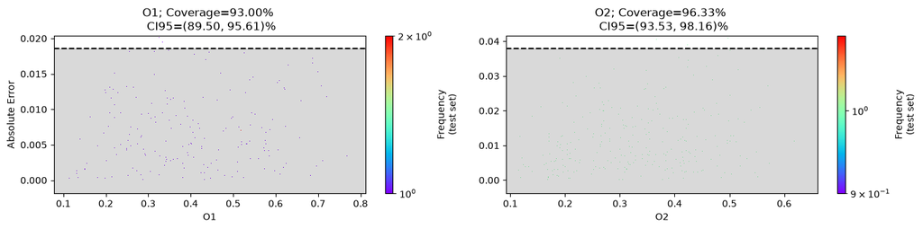

```python
# Global uncertainty model
uncert_model_global = validationlib.tests.interval.BinnedUncertaintyModel(
    percentile_range=percentile_range,
    model_type="eqspaced_bins",
    ci_type=ci_type,
    method_kwargs={"bins":1, "nsim":100, "min_elems": min_elems, "conf": 0.95},
    matched_analysis=True
)
uncert_model_global.train(
    yh_valtest_df,
    abserr_metric(yt_valtest_df, yh_valtest_df),
    val_mask, # We can give a mask of the validation data to train the model
    x_variables=yt_test_df.columns,
    y_variables=yt_test_df.columns
)

# If we have a split of data, different than the one used to train the uncertainty model, we can create a ModelCoverage object to compute the coverage of the model.
cov_model = validationlib.tests.interval.ModelCoverage(matched_analysis=True, conf=0.95)
coverage_df, coverageci_df = cov_model.compute_coverage(
    yh_valtest_df,
    abserr_metric(yt_valtest_df, yh_valtest_df),
    test_mask, # The coverage is computed for the test data (as this split has not been used yet)
    uncert_model_global, # Uncertainty model
    x_variables=yt_test_df.columns,
    y_variables=yt_test_df.columns,
)

# We can complete the scatterplot with another split of data (e.g. the test data), and the coverage model
uncert_model_global.coverage_plot(
    yh_valtest_df,
    abserr_metric(yt_valtest_df, yh_valtest_df),
    val_mask,
    test_mask,
    cov_model,
    y_label=abserr_metric.name,
    plot_type="histogram",
    hist_data="test",
    bins=500,
    logscale=True
)
plt.show()
```

```python
tables = uncert_model_global.get_tables()
for table in tables:
    display(table)
```

Input: O1; Output: O1

|  | [0.07754, 0.8116] |
| --- | --- |
| Mean | 0.007554 |
| CI | [-inf, 0.01853] |

Input: O2; Output: O2

|  | [0.09239, 0.6614] |
| --- | --- |
| Mean | 0.01365 |
| CI | [-inf, 0.0378] |

#### Local Uncertainty Model. Output Conditioned

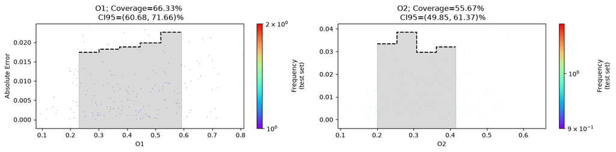

```python
# Uncertainty model output
uncert_model_localoutput = validationlib.tests.interval.BinnedUncertaintyModel(
    percentile_range=percentile_range,
    model_type="eqspaced_bins",
    ci_type=ci_type,
    method_kwargs={"bins":n_bins_local, "nsim":100, "min_elems": min_elems, "conf": 0.95},
    matched_analysis=True
)
uncert_model_localoutput.train(
    yh_valtest_df,
    abserr_metric(yt_valtest_df, yh_valtest_df),
    val_mask,
    x_variables=yt_test_df.columns,
    y_variables=yt_test_df.columns
)

cov_model = validationlib.tests.interval.ModelCoverage(matched_analysis=True, conf=0.95)
coverage_df, coverageci_df = cov_model.compute_coverage(
    yh_valtest_df,
    abserr_metric(yt_valtest_df, yh_valtest_df),
    test_mask,
    uncert_model_localoutput,
    x_variables=yt_test_df.columns,
    y_variables=yt_test_df.columns,
)

uncert_model_localoutput.coverage_plot(
    yh_valtest_df,
    abserr_metric(yt_valtest_df, yh_valtest_df),
    val_mask,
    test_mask,
    cov_model,
    y_label=abserr_metric.name,
    plot_type="histogram",
    hist_data="test",
    bins=500,
    logscale=True
)
plt.show()
```

```python
tables = uncert_model_localoutput.get_tables()
for table in tables:
    display(table)
```

Input: O1; Output: O1

|  | [0.07754, 0.1567] | [0.1567, 0.2291] | [0.2291, 0.3016] | [0.3016, 0.374] | [0.374, 0.4464] | [0.4464, 0.5189] | [0.5189, 0.5913] | [0.5913, 0.6637] | [0.6637, 0.7361] | [0.7361, 0.8116] |
| --- | --- | --- | --- | --- | --- | --- | --- | --- | --- | --- |
| Mean | nan | nan | 0.007391 | 0.008311 | 0.007292 | 0.007896 | 0.008759 | nan | nan | nan |
| CI | [nan, nan] | [nan, nan] | [-inf, 0.01745] | [-inf, 0.01826] | [-inf, 0.01878] | [-inf, 0.01983] | [-inf, 0.02258] | [nan, nan] | [nan, nan] | [nan, nan] |

Input: O2; Output: O2

|  | [0.09239, 0.1471] | [0.1471, 0.2007] | [0.2007, 0.2543] | [0.2543, 0.3079] | [0.3079, 0.3615] | [0.3615, 0.4152] | [0.4152, 0.4688] | [0.4688, 0.5224] | [0.5224, 0.576] | [0.576, 0.6614] |
| --- | --- | --- | --- | --- | --- | --- | --- | --- | --- | --- |
| Mean | nan | nan | 0.01094 | 0.01467 | 0.01388 | 0.01167 | nan | nan | nan | nan |
| CI | [nan, nan] | [nan, nan] | [-inf, 0.03348] | [-inf, 0.03841] | [-inf, 0.02971] | [-inf, 0.03194] | [nan, nan] | [nan, nan] | [nan, nan] | [nan, nan] |

#### Local Uncertainty Model. Input Conditioned

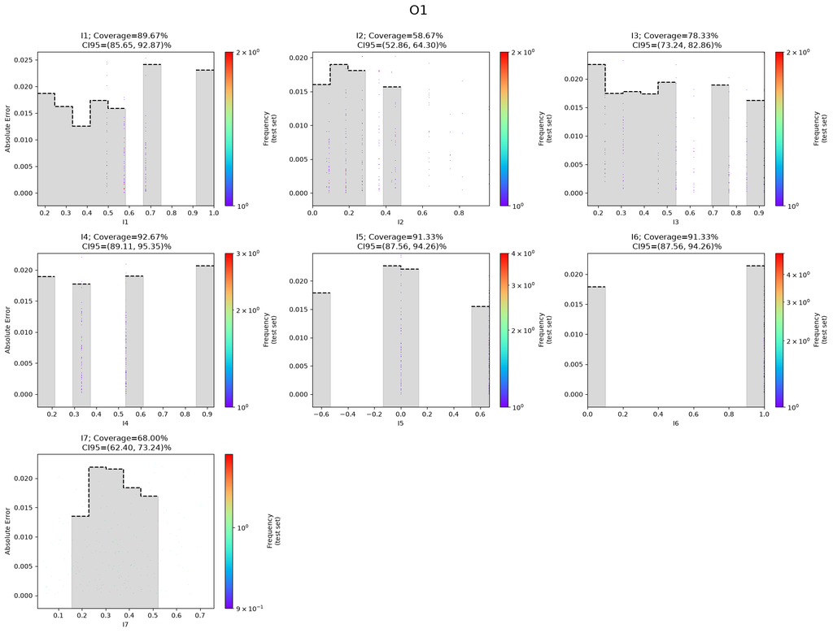

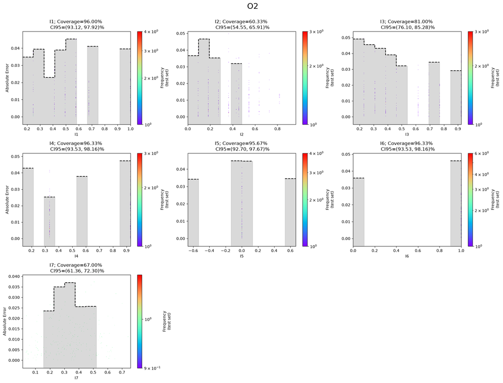

```python
# Uncertainty model numerical inputs
uncert_model_localinput_num = validationlib.tests.interval.BinnedUncertaintyModel(
    percentile_range=percentile_range,
    model_type="eqspaced_bins",
    ci_type=ci_type,
    method_kwargs={"bins":n_bins_local, "nsim":100, "min_elems": min_elems, "conf": 0.95},
    matched_analysis=False
)
uncert_model_localinput_num.train(
    x_valtest_df,
    abserr_metric(yt_valtest_df, yh_valtest_df),
    val_mask,
    x_variables=x_test_df.columns,
    y_variables=yt_test_df.columns
)

cov_modelnum = validationlib.tests.interval.ModelCoverage(matched_analysis=False, conf=0.95)
coverage_df, coverageci_df = cov_modelnum.compute_coverage(
    x_valtest_df,
    abserr_metric(yt_valtest_df, yh_valtest_df),
    test_mask,
    uncert_model_localinput_num,
    x_variables=x_test_df.columns,
    y_variables=yt_test_df.columns,
)

uncert_model_localinput_num.coverage_plot(
    x_valtest_df,
    abserr_metric(yt_valtest_df, yh_valtest_df),
    val_mask,
    test_mask,
    cov_modelnum,
    y_label=abserr_metric.name,
    plot_type="histogram",
    hist_data="test",
    bins=500,
    logscale=True
)
plt.show()
```

```python
tables = uncert_model_localinput_num.get_tables()
for table in tables:
    display(table)
```

Input: I1; Output: O1

|  | [0.1646, 0.2481] | [0.2481, 0.3317] | [0.3317, 0.4152] | [0.4152, 0.4988] | [0.4988, 0.5823] | [0.5823, 0.6658] | [0.6658, 0.7494] | [0.7494, 0.8329] | [0.8329, 0.9165] | [0.9165, 1] |
| --- | --- | --- | --- | --- | --- | --- | --- | --- | --- | --- |
| Mean | 0.007489 | 0.007004 | 0.005408 | 0.007267 | 0.006724 | nan | 0.008361 | nan | nan | 0.01129 |
| CI | [-inf, 0.0187] | [-inf, 0.01624] | [-inf, 0.01251] | [-inf, 0.01738] | [-inf, 0.01585] | [nan, nan] | [-inf, 0.02411] | [nan, nan] | [nan, nan] | [-inf, 0.02309] |

Input: I2; Output: O1

|  | [0, 0.09636] | [0.09636, 0.1927] | [0.1927, 0.2891] | [0.2891, 0.3855] | [0.3855, 0.4818] | [0.4818, 0.5782] | [0.5782, 0.6745] | [0.6745, 0.7709] | [0.7709, 0.8673] | [0.8673, 0.9636] |
| --- | --- | --- | --- | --- | --- | --- | --- | --- | --- | --- |
| Mean | 0.006459 | 0.008598 | 0.007034 | nan | 0.006049 | nan | nan | nan | nan | nan |
| CI | [-inf, 0.01602] | [-inf, 0.01898] | [-inf, 0.01807] | [nan, nan] | [-inf, 0.01565] | [nan, nan] | [nan, nan] | [nan, nan] | [nan, nan] | [nan, nan] |

Input: I3; Output: O1

|  | [0.1538, 0.2308] | [0.2308, 0.3077] | [0.3077, 0.3846] | [0.3846, 0.4615] | [0.4615, 0.5385] | [0.5385, 0.6154] | [0.6154, 0.6923] | [0.6923, 0.7692] | [0.7692, 0.8462] | [0.8462, 0.9231] |
| --- | --- | --- | --- | --- | --- | --- | --- | --- | --- | --- |
| Mean | 0.008657 | 0.007245 | 0.007126 | 0.006873 | 0.007966 | nan | nan | 0.007617 | nan | 0.006537 |
| CI | [-inf, 0.02251] | [-inf, 0.01748] | [-inf, 0.01776] | [-inf, 0.01738] | [-inf, 0.01943] | [nan, nan] | [nan, nan] | [-inf, 0.01891] | [nan, nan] | [-inf, 0.01626] |

Input: I4; Output: O1

|  | [0.1333, 0.213] | [0.213, 0.2927] | [0.2927, 0.3723] | [0.3723, 0.452] | [0.452, 0.5317] | [0.5317, 0.6113] | [0.6113, 0.691] | [0.691, 0.7707] | [0.7707, 0.8503] | [0.8503, 0.93] |
| --- | --- | --- | --- | --- | --- | --- | --- | --- | --- | --- |
| Mean | 0.007408 | nan | 0.00717 | nan | nan | 0.007333 | nan | nan | nan | 0.008378 |
| CI | [-inf, 0.01898] | [nan, nan] | [-inf, 0.01773] | [nan, nan] | [nan, nan] | [-inf, 0.019] | [nan, nan] | [nan, nan] | [nan, nan] | [-inf, 0.02067] |

Input: I5; Output: O1

|  | [-0.6667, -0.5333] | [-0.5333, -0.4] | [-0.4, -0.2667] | [-0.2667, -0.1333] | [-0.1333, 0] | [0, 0.1333] | [0.1333, 0.2667] | [0.2667, 0.4] | [0.4, 0.5333] | [0.5333, 0.6667] |
| --- | --- | --- | --- | --- | --- | --- | --- | --- | --- | --- |
| Mean | 0.006799 | nan | nan | nan | 0.009171 | 0.009263 | nan | nan | nan | 0.006683 |
| CI | [-inf, 0.01787] | [nan, nan] | [nan, nan] | [nan, nan] | [-inf, 0.02268] | [-inf, 0.02208] | [nan, nan] | [nan, nan] | [nan, nan] | [-inf, 0.01549] |

Input: I6; Output: O1

|  | [0, 0.1] | [0.1, 0.2] | [0.2, 0.3] | [0.3, 0.4] | [0.4, 0.5] | [0.5, 0.6] | [0.6, 0.7] | [0.7, 0.8] | [0.8, 0.9] | [0.9, 1] |
| --- | --- | --- | --- | --- | --- | --- | --- | --- | --- | --- |
| Mean | 0.007246 | nan | nan | nan | nan | nan | nan | nan | nan | 0.008603 |
| CI | [-inf, 0.01791] | [nan, nan] | [nan, nan] | [nan, nan] | [nan, nan] | [nan, nan] | [nan, nan] | [nan, nan] | [nan, nan] | [-inf, 0.0214] |

Input: I7; Output: O1

|  | [0.0104, 0.08168] | [0.08168, 0.1552] | [0.1552, 0.2286] | [0.2286, 0.3021] | [0.3021, 0.3756] | [0.3756, 0.4491] | [0.4491, 0.5226] | [0.5226, 0.596] | [0.596, 0.6695] | [0.6695, 0.7584] |
| --- | --- | --- | --- | --- | --- | --- | --- | --- | --- | --- |
| Mean | nan | nan | 0.006644 | 0.009441 | 0.007755 | 0.006939 | 0.00864 | nan | nan | nan |
| CI | [nan, nan] | [nan, nan] | [-inf, 0.01352] | [-inf, 0.02191] | [-inf, 0.0216] | [-inf, 0.01837] | [-inf, 0.01697] | [nan, nan] | [nan, nan] | [nan, nan] |

Input: I1; Output: O2

|  | [0.1646, 0.2481] | [0.2481, 0.3317] | [0.3317, 0.4152] | [0.4152, 0.4988] | [0.4988, 0.5823] | [0.5823, 0.6658] | [0.6658, 0.7494] | [0.7494, 0.8329] | [0.8329, 0.9165] | [0.9165, 1] |
| --- | --- | --- | --- | --- | --- | --- | --- | --- | --- | --- |
| Mean | 0.01135 | 0.01367 | 0.01135 | 0.01376 | 0.0162 | nan | 0.01426 | nan | nan | 0.01657 |
| CI | [-inf, 0.03479] | [-inf, 0.03935] | [-inf, 0.02288] | [-inf, 0.03888] | [-inf, 0.04531] | [nan, nan] | [-inf, 0.04101] | [nan, nan] | [nan, nan] | [-inf, 0.03955] |

Input: I2; Output: O2

|  | [0, 0.09636] | [0.09636, 0.1927] | [0.1927, 0.2891] | [0.2891, 0.3855] | [0.3855, 0.4818] | [0.4818, 0.5782] | [0.5782, 0.6745] | [0.6745, 0.7709] | [0.7709, 0.8673] | [0.8673, 0.9636] |
| --- | --- | --- | --- | --- | --- | --- | --- | --- | --- | --- |
| Mean | 0.01254 | 0.01546 | 0.01302 | nan | 0.01345 | nan | nan | nan | nan | nan |
| CI | [-inf, 0.03656] | [-inf, 0.04657] | [-inf, 0.0353] | [nan, nan] | [-inf, 0.0318] | [nan, nan] | [nan, nan] | [nan, nan] | [nan, nan] | [nan, nan] |

Input: I3; Output: O2

|  | [0.1538, 0.2308] | [0.2308, 0.3077] | [0.3077, 0.3846] | [0.3846, 0.4615] | [0.4615, 0.5385] | [0.5385, 0.6154] | [0.6154, 0.6923] | [0.6923, 0.7692] | [0.7692, 0.8462] | [0.8462, 0.9231] |
| --- | --- | --- | --- | --- | --- | --- | --- | --- | --- | --- |
| Mean | 0.01777 | 0.0133 | 0.0129 | 0.01464 | 0.01295 | nan | nan | 0.01274 | nan | 0.00902 |
| CI | [-inf, 0.04904] | [-inf, 0.04559] | [-inf, 0.04321] | [-inf, 0.03916] | [-inf, 0.03209] | [nan, nan] | [nan, nan] | [-inf, 0.03439] | [nan, nan] | [-inf, 0.02912] |

Input: I4; Output: O2

|  | [0.1333, 0.213] | [0.213, 0.2927] | [0.2927, 0.3723] | [0.3723, 0.452] | [0.452, 0.5317] | [0.5317, 0.6113] | [0.6113, 0.691] | [0.691, 0.7707] | [0.7707, 0.8503] | [0.8503, 0.93] |
| --- | --- | --- | --- | --- | --- | --- | --- | --- | --- | --- |
| Mean | 0.01646 | nan | 0.01009 | nan | nan | 0.01422 | nan | nan | nan | 0.01554 |
| CI | [-inf, 0.04285] | [nan, nan] | [-inf, 0.02532] | [nan, nan] | [nan, nan] | [-inf, 0.03793] | [nan, nan] | [nan, nan] | [nan, nan] | [-inf, 0.04732] |

Input: I5; Output: O2

|  | [-0.6667, -0.5333] | [-0.5333, -0.4] | [-0.4, -0.2667] | [-0.2667, -0.1333] | [-0.1333, 0] | [0, 0.1333] | [0.1333, 0.2667] | [0.2667, 0.4] | [0.4, 0.5333] | [0.5333, 0.6667] |
| --- | --- | --- | --- | --- | --- | --- | --- | --- | --- | --- |
| Mean | 0.01268 | nan | nan | nan | 0.01608 | 0.01611 | nan | nan | nan | 0.01281 |
| CI | [-inf, 0.03413] | [nan, nan] | [nan, nan] | [nan, nan] | [-inf, 0.04479] | [-inf, 0.04467] | [nan, nan] | [nan, nan] | [nan, nan] | [-inf, 0.03445] |

Input: I6; Output: O2

|  | [0, 0.1] | [0.1, 0.2] | [0.2, 0.3] | [0.3, 0.4] | [0.4, 0.5] | [0.5, 0.6] | [0.6, 0.7] | [0.7, 0.8] | [0.8, 0.9] | [0.9, 1] |
| --- | --- | --- | --- | --- | --- | --- | --- | --- | --- | --- |
| Mean | 0.01309 | nan | nan | nan | nan | nan | nan | nan | nan | 0.01623 |
| CI | [-inf, 0.03582] | [nan, nan] | [nan, nan] | [nan, nan] | [nan, nan] | [nan, nan] | [nan, nan] | [nan, nan] | [nan, nan] | [-inf, 0.04606] |

Input: I7; Output: O2

|  | [0.0104, 0.08168] | [0.08168, 0.1552] | [0.1552, 0.2286] | [0.2286, 0.3021] | [0.3021, 0.3756] | [0.3756, 0.4491] | [0.4491, 0.5226] | [0.5226, 0.596] | [0.596, 0.6695] | [0.6695, 0.7584] |
| --- | --- | --- | --- | --- | --- | --- | --- | --- | --- | --- |
| Mean | nan | nan | 0.007153 | 0.01535 | 0.01508 | 0.01023 | 0.01162 | nan | nan | nan |
| CI | [nan, nan] | [nan, nan] | [-inf, 0.02354] | [-inf, 0.03497] | [-inf, 0.03702] | [-inf, 0.02549] | [-inf, 0.02567] | [nan, nan] | [nan, nan] | [nan, nan] |

#### Full Uncertainty Model

We can also combine all the previous uncertainty models in a single uncert. model. This model will output, given a sample, the biggest possible confidence interval from the output of all models.

Similarly to what we have done before, we can check the performance of this model by computing its coverage:

```python
# We can combine all the uncertainty models (global, output, numerical inputs and categorical inputs) in a single model
# This model will output, given a sample, the biggest possible confidence interval from the output of all models

# Compute predictions of all models
full_uncert_model = validationlib.tests.interval.CombinedUncertaintyModel(
    uncert_model_global, uncert_model_localoutput, uncert_model_localinput_num
)

full_uncert_preds = full_uncert_model.predict(
    x_valtest_df.join(yh_valtest_df),
    test_mask,
    x_variables=yt_test_df.columns,
    y_variables=yt_test_df.columns
)

# Coverage check
cov_model_full = validationlib.tests.interval.ModelCoverage(matched_analysis=True, conf=0.95)
coverage_df, coverageci_df = cov_model_full.compute_coverage(
    yh_valtest_df,
    abserr_metric(yt_valtest_df, yh_valtest_df),
    test_mask,
    model_predictions=full_uncert_preds,
    x_variables=yt_test_df.columns,
    y_variables=yt_test_df.columns,
)

print("Coverage of full model (by output variable):")
for out_var in yt_test_df.columns:
    print(f"{out_var}: {coverage_df.loc[out_var,out_var]}; CI95: {coverageci_df.loc[out_var,out_var]}")
```

```
Coverage of full model (by output variable):
O1: 96.0; CI95: [93.11710118 97.91634237]
O2: 98.33333333333333; CI95: [96.1536255  99.45667947]
```